# Sistema de Recomendación por Reglas de Asociación

Apriori · FP-Growth · ECLAT — Dataset MovieLens 100K

Autor/a

Alejandro Figueroa Rojas | Ingeniero Comercial — Data & Business Intelligence

Fecha de publicación

23 de mayo de 2026

# 1 Resumen Ejecutivo

[output not shown]

# 2 Motivación y Objetivos

## 2.1 Contexto del Problema

Las plataformas de *streaming* enfrentan un problema central: el **exceso de opciones**. Netflix, Amazon Prime y similares ofrecen catálogos de miles de títulos; la paradoja de la elección lleva a que los usuarios pasen más tiempo buscando que consumiendo. Los sistemas de recomendación son la respuesta estructural a este problema.

Las **reglas de asociación** ofrecen un enfoque interpretable y no supervisado: identifican patrones de co-visualización del tipo *“usuarios que vieron $A$ también vieron $B$”*, generando recomendaciones basadas en el comportamiento colectivo real. A diferencia de los filtros colaborativos matriciales (SVD, ALS, NCF), las reglas son explícitas, auditables y no requieren reentrenamiento continuo.

## 2.2 Objetivos

**Objetivo general:** construir un sistema de recomendación basado en reglas de asociación sobre MovieLens 100K, evaluando y comparando tres algoritmos de minería de patrones frecuentes.

**Objetivos específicos:**

1. Describir la estructura del dataset mediante EDA completo, incluyendo diagnóstico de calidad de datos.
2. Detectar y documentar valores faltantes, sparsity, y usuarios atípicos.
3. Transformar la matriz de ratings en transacciones binarias interpretables.
4. Aplicar el **Clean Algorithm** (filtro de soporte + correlación iterativa) para reducir ruido y redundancia.
5. Ejecutar Apriori, FP-Growth y ECLAT sobre las mismas transacciones limpias.
6. Comparar rendimiento: número de reglas, métricas de calidad y tiempo de ejecución.
7. Construir un motor de recomendación por perfil de género con los tres algoritmos.
8. Interpretar y validar las reglas generadas desde la perspectiva del dominio cinematográfico.

## 2.3 Diagrama del Pipeline

↓

**Paso 2 — EDA + Diagnóstico de calidad**  
Distribuciones · NAs · Sparsity · Outliers · Géneros

↓

**Paso 3 — Binarización**  
Rating ≥ 4 → transacción positiva

↓

[output not shown]

[output not shown]

*Pasos 4a + 4b = Clean Algorithm → transacciones limpias (trans_final)*

↓

[output not shown]

[output not shown]

[output not shown]

↓

**Paso 6 — Comparativa**  
Lift · Confianza · Conviction · Leverage · Tiempo

↓

**Paso 7 — Motor de Recomendación**  
Recomendación por perfil de género

# 3 Fundamentos Matemáticos

## 3.1 Notación Base

Sea $\mathcal{I} = \{i_1, i_2, \ldots, i_m\}$ el universo de películas y $\mathcal{D} = \{T_1, T_2, \ldots, T_n\}$ el conjunto de transacciones, donde cada $T_k \subseteq \mathcal{I}$ representa las películas que el usuario $k$ valoró positivamente (rating $\geq 4$).

El **soporte absoluto** de un itemset $X$:

$$\sigma(X) = \left|\{T_k \in \mathcal{D} : X \subseteq T_k\}\right|$$

El **soporte relativo**:

$$\text{supp}(X) = \frac{\sigma(X)}{|\mathcal{D}|}$$

## 3.2 Regla de Asociación

$$A \Rightarrow B \quad \text{donde } A, B \subseteq \mathcal{I},\; A \cap B = \emptyset,\; A \neq \emptyset,\; B \neq \emptyset$$

## 3.3 Métricas de Evaluación

### 3.3.1 Soporte

$$\text{supp}(A \Rightarrow B) = \frac{\sigma(A \cup B)}{|\mathcal{D}|}$$

### 3.3.2 Confianza

$$\text{conf}(A \Rightarrow B) = \frac{\text{supp}(A \cup B)}{\text{supp}(A)} = P(B \mid A)$$

### 3.3.3 Lift

$$\text{lift}(A \Rightarrow B) = \frac{\text{conf}(A \Rightarrow B)}{\text{supp}(B)} = \frac{P(A \cap B)}{P(A) \cdot P(B)}$$

- $\text{lift} > 1$: asociación real (co-visualización más frecuente de lo esperado bajo independencia).
- $\text{lift} = 1$: independencia estadística — regla trivial.
- $\text{lift} < 1$: asociación negativa.

### 3.3.4 Conviction

$$\text{conv}(A \Rightarrow B) = \frac{1 - \text{supp}(B)}{1 - \text{conf}(A \Rightarrow B)}$$

Mide qué tan fuertemente $A$ implica $B$. Toma valor $\infty$ cuando $\text{conf} = 1$.

### 3.3.5 Leverage

$$\text{lev}(A \Rightarrow B) = \text{supp}(A \cup B) - \text{supp}(A) \cdot \text{supp}(B)$$

Diferencia entre co-ocurrencia observada y esperada bajo independencia. $\text{lev} = 0$ equivale a $\text{lift} = 1$.

## 3.4 Clean Algorithm

**Paso 4a — Filtro de soporte mínimo:**

$$\text{Eliminar película } i_j \iff \text{supp}(\{i_j\}) < \text{minsup}$$

**Paso 4b — Filtro de correlación iterativo:**

$$\text{Eliminar } i_j \iff \exists\, i_k : |r(i_j, i_k)| \geq 0.90$$

Películas altamente correladas generan reglas redundantes. Se itera hasta convergencia:

$$\max_{j \neq k} |r(i_j, i_k)| < 0.90$$

## 3.5 Algoritmos

### 3.5.1 Apriori — Propiedad Antimonotónica

$$\text{Si } \text{supp}(X) < \text{minsup} \Rightarrow \forall Y \supset X: \text{supp}(Y) < \text{minsup}$$

Generación de candidatos $C_{k+1}$ a partir de los itemsets frecuentes $F_k$, con poda de subconjuntos infrecuentes. Requiere múltiples escaneos de la base.

### 3.5.2 FP-Growth — Árbol Comprimido

Construye un FP-tree con prefijos compartidos en **2 escaneos**. La minería es recursiva sobre bases de patrones condicionales $\mathcal{D}_i$ para cada ítem $i$, sin generar candidatos explícitos.

### 3.5.3 ECLAT — Representación Vertical

Cada ítem almacena su **tidset**: $\text{tidset}(X) = \{k : X \subseteq T_k\}$.

$$\sigma(X \cup Y) = |\text{tidset}(X) \cap \text{tidset}(Y)|$$

Solo requiere **1 escaneo** inicial. El soporte se calcula íntegramente por intersección de conjuntos.

# 4 Paso 1: Carga y Descripción del Dataset

## 4.1 Descripción de MovieLens 100K

Descripción del dataset MovieLens 100K

[output not shown]

## 4.2 Carga y Verificación Inicial

```r
data(MovieLense)

mat_raw  <- as(MovieLense, "matrix")
n_users  <- nrow(MovieLense)
n_items  <- ncol(MovieLense)
n_rat    <- sum(!is.na(mat_raw))
densidad <- round(n_rat / (n_users * n_items), 4)

cat(
  "── MovieLens 100K ───────────────────────────────────────\n",
  "Clase           :", class(MovieLense), "\n",
  "Usuarios        :", n_users,           "\n",
  "Películas       :", n_items,           "\n",
  "Ratings totales :", n_rat,             "\n",
  "Densidad        :", densidad,          "\n",
  "Rating promedio :", round(mean(getRatings(MovieLense)), 3), "\n",
  "Rating mediano  :", median(getRatings(MovieLense)),         "\n"
)
```

```
── MovieLens 100K ───────────────────────────────────────
 Clase           : realRatingMatrix
 Usuarios        : 943
 Películas       : 1664
 Ratings totales : 99392
 Densidad        : 0.0633
 Rating promedio : 3.53
 Rating mediano  : 4
```

# 5 Paso 2: EDA y Diagnóstico de Calidad de Datos

## 5.1 Diagnóstico de Valores Faltantes y Estructura Sparse

La matriz usuario-película de MovieLens es **inherentemente sparse**: la mayoría de las celdas son `NA` porque un usuario no ha calificado la mayoría de las películas. Es fundamental distinguir entre:

- **NA estructural:** el usuario nunca vio la película — no es un dato faltante en sentido estadístico, sino ausencia de interacción.
- **NA aleatorio:** dato genuinamente perdido — no aplica en este dataset (todos los ratings registrados son observados).

```r
# Matriz completa de ratings (NA = no calificado)
n_total   <- n_users * n_items
n_obs     <- sum(!is.na(mat_raw))
n_na      <- sum(is.na(mat_raw))
pct_obs   <- round(100 * n_obs / n_total, 2)
pct_na    <- round(100 * n_na  / n_total, 2)

# Usuarios sin ningún rating (no debería existir dado el diseño del dataset)
users_sin_rating <- sum(rowSums(!is.na(mat_raw)) == 0)
# Películas sin ningún rating
items_sin_rating <- sum(colSums(!is.na(mat_raw)) == 0)

cat(
  "── Diagnóstico de estructura de datos ──────────────────\n",
  "Celdas totales (usuarios × películas) :", format(n_total, big.mark = " "), "\n",
  "Celdas con rating observado           :", format(n_obs,   big.mark = " "),
  " (", pct_obs, "% densidad)\n",
  "Celdas sin rating (NA estructural)    :", format(n_na,    big.mark = " "),
  " (", pct_na,  "%)\n",
  "Usuarios sin ningún rating            :", users_sin_rating, "\n",
  "Películas sin ningún rating           :", items_sin_rating, "\n"
)
```

```
── Diagnóstico de estructura de datos ──────────────────
 Celdas totales (usuarios × películas) : 1 569 152
 Celdas con rating observado           : 99 392  ( 6.33 % densidad)
 Celdas sin rating (NA estructural)    : 1 469 760  ( 93.67 %)
 Usuarios sin ningún rating            : 0
 Películas sin ningún rating           : 0
```

Diagnóstico de completitud de la matriz usuario-película

| Concepto | N | Porcentaje |
| --- | --- | --- |
| Celdas totales (usuarios × películas) | 1 569 152 | 100 % |
| Ratings observados | 99 392 | 6.33 % |
| Ausencias (NA estructural — no visto) | 1 469 760 | 93.67 % |
| Usuarios sin ningún rating | 0 | 0 % |
| Películas sin ningún rating | 0 | 0 % |

> **Interpretación:** el 93.67 % de ausencias es NA estructural y no representa datos corrompidos. No se aplica imputación. La binarización posterior (rating ≥ 4) convierte estas ausencias en cero de forma correcta.

## 5.2 Distribución de Ratings

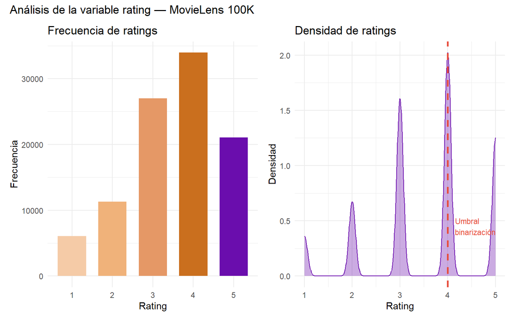

Distribución de ratings — MovieLens 100K

```r
rat_vec <- getRatings(MovieLense)
rat_df  <- data.frame(rating = rat_vec)

rat_tab <- data.frame(
  Rating = 1:5,
  N      = as.integer(table(rat_vec)),
  Pct    = round(100 * as.numeric(table(rat_vec)) / length(rat_vec), 2)
)

p1 <- ggplot(rat_df, aes(x = factor(rating), fill = factor(rating))) +
  geom_bar(width = 0.7) +
  scale_fill_manual(values = c("#f5cba7", "#f0b27a", "#e59866", "#ca6f1e", COL_A)) +
  labs(title = "Frecuencia de ratings", x = "Rating", y = "Frecuencia") +
  theme(legend.position = "none")

p2 <- ggplot(rat_df, aes(x = rating)) +
  geom_density(fill = COL_A, alpha = 0.35, color = COL_A) +
  geom_vline(xintercept = 4, linetype = "dashed", color = COL_W, linewidth = 0.9) +
  annotate("text", x = 4.15, y = 0.45, label = "Umbral\nbinarización",
           color = COL_W, size = 3, hjust = 0) +
  labs(title = "Densidad de ratings", x = "Rating", y = "Densidad")

p1 + p2 +
  plot_annotation(title = "Análisis de la variable rating — MovieLens 100K")
```

**Umbral de binarización**

Un rating $\geq 4$ se interpreta como preferencia positiva y se convierte en $1$; cualquier valor inferior o ausente se convierte en $0$:

$$x_{ui} = \begin{cases} 1 & r_{ui} \geq 4 \\ 0 & \text{si no} \end{cases}$$

El pico de densidad exactamente en rating = 4 confirma que es el corte natural. Ratings 1–3 reflejan indiferencia o rechazo y no deben incluirse en las transacciones.

Distribución de frecuencias de ratings

| Rating | N observaciones | % del total |
| --- | --- | --- |
| 1 | 6059 | 6.10 |
| 2 | 11307 | 11.38 |
| 3 | 27002 | 27.17 |
| 4 | 33947 | 34.15 |
| 5 | 21077 | 21.21 |

> **Nota:** los ratings 4 y 5 representan el 55.4 % del total, lo que valida el umbral ≥ 4 como definición de preferencia positiva con masa suficiente para extraer patrones.

## 5.3 Detección de Outliers — Actividad por Usuario

```r
rat_por_user <- data.frame(
  user     = rownames(MovieLense),
  n_rat    = rowCounts(MovieLense),
  mean_rat = rowMeans(MovieLense, na.rm = TRUE)
)

Q1_u      <- quantile(rat_por_user$n_rat, 0.25)
Q3_u      <- quantile(rat_por_user$n_rat, 0.75)
IQR_u     <- Q3_u - Q1_u
lim_sup_u <- Q3_u + 1.5 * IQR_u
outliers_u <- rat_por_user[rat_por_user$n_rat > lim_sup_u, ]

cat("── Outliers por actividad (método IQR) ─────────────────\n",
    "Límite superior (Q3 + 1.5·IQR) :", round(lim_sup_u), "ratings\n",
    "Usuarios outlier                :", nrow(outliers_u),
    "(", round(100 * nrow(outliers_u) / nrow(rat_por_user), 1), "% del total)\n")
```

```
── Outliers por actividad (método IQR) ─────────────────
 Límite superior (Q3 + 1.5·IQR) : 321 ratings
 Usuarios outlier                : 41 ( 4.3 % del total)
```

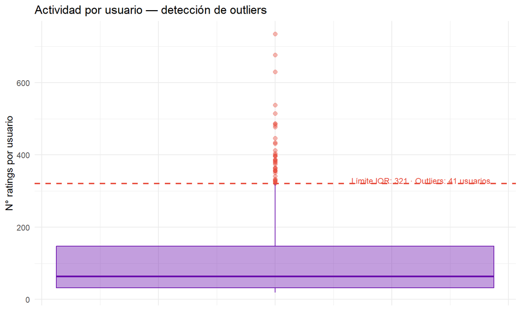

Detección de outliers por actividad de usuario (IQR)

```r
ggplot(rat_por_user, aes(y = n_rat)) +
  geom_boxplot(fill = COL_A, alpha = 0.4, color = COL_A,
               outlier.color = COL_W, outlier.size = 2) +
  geom_hline(yintercept = lim_sup_u, linetype = "dashed",
             color = COL_W, linewidth = 0.8) +
  annotate("text", x = 0.25, y = lim_sup_u + 8,
           label = paste0("Límite IQR: ", round(lim_sup_u),
                          " · Outliers: ", nrow(outliers_u), " usuarios"),
           color = COL_W, size = 3.2) +
  labs(title = "Actividad por usuario — detección de outliers",
       y = "N° ratings por usuario", x = "") +
  theme(axis.text.x = element_blank())
```

**Interpretacion resultados**

El gráfico muestra la distribución del número de *ratings* por usuario mediante un **boxplot** con detección de outliers por el método IQR.

- La **caja morada** concentra el 50% central de los usuarios (entre el percentil 25 y el 75), con una mediana cercana a los 60 ratings, lo que indica que la mayoría de los usuarios tiene actividad moderada y bastante homogénea.
- La **línea discontinua roja** marca el límite superior IQR (Q3 + 1.5 × IQR = 321 ratings). Los **41 usuarios** que superan ese umbral se clasifican como outliers: son usuarios excepcionalmente activos, con hasta más de 700 ratings.
- La distribución es fuertemente **asimétrica a la derecha**: la gran masa de usuarios califica poco, mientras una minoría concentra una actividad desproporcionada.

Estadísticos de actividad por usuario

| Estadístico | Valor |
| --- | --- |
| Media | 105.4 |
| Mediana | 64.0 |
| Mín | 19.0 |
| Máx | 735.0 |
| Q1 | 32.0 |
| Q3 | 147.5 |
| IQR | 115.5 |
| Límite superior (Q3 + 1.5·IQR) | 321.0 |
| Usuarios outlier (superan límite) | 41.0 |

> **Usuarios con actividad extrema (> 321 ratings):** 41 usuarios. Estos usuarios de alta actividad tienen un peso desproporcionado en el cálculo del soporte. Se mantienen en el análisis dado que representan usuarios genuinamente activos, no errores de datos; sin embargo, el filtro de soporte mínimo (Paso 4a) mitiga su influencia al exigir que un patrón sea frecuente en la **base completa**.

## 5.4 Detección de Outliers — Actividad por Película

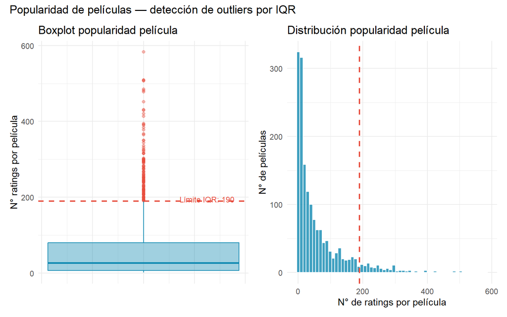

Distribución de popularidad por película

```r
rat_por_item <- data.frame(
  item   = colnames(MovieLense),
  n_rat  = colCounts(MovieLense),
  mean_r = colMeans(MovieLense, na.rm = TRUE)
)

Q1_i  <- quantile(rat_por_item$n_rat, 0.25)
Q3_i  <- quantile(rat_por_item$n_rat, 0.75)
IQR_i <- Q3_i - Q1_i
lim_sup_i <- Q3_i + 1.5 * IQR_i
outliers_i <- rat_por_item[rat_por_item$n_rat > lim_sup_i, ]

p_box_i <- ggplot(rat_por_item, aes(y = n_rat)) +
  geom_boxplot(fill = COL_F, alpha = 0.4, color = COL_F,
               outlier.color = COL_W, outlier.size = 1.5) +
  geom_hline(yintercept = lim_sup_i, linetype = "dashed",
             color = COL_W, linewidth = 0.8) +
  annotate("text", x = 0.25, y = lim_sup_i + 5,
           label = paste0("Límite IQR: ", round(lim_sup_i)),
           color = COL_W, size = 3.2) +
  labs(title = "Boxplot popularidad película",
       y = "N° ratings por película", x = "") +
  theme(axis.text.x = element_blank())

p_hist_i <- ggplot(rat_por_item, aes(x = n_rat)) +
  geom_histogram(bins = 60, fill = COL_F, color = "white", alpha = 0.8) +
  geom_vline(xintercept = lim_sup_i, linetype = "dashed",
             color = COL_W, linewidth = 0.8) +
  labs(title = "Distribución popularidad película",
       x = "N° de ratings por película", y = "N° de películas")

p_box_i + p_hist_i +
  plot_annotation(title = "Popularidad de películas — detección de outliers por IQR")
```

El panel combina un **boxplot** e **histograma** para analizar la popularidad de películas (medida en número de ratings recibidos).

**Boxplot (izquierda)**

La caja celeste concentra el 50% central de las películas, con una mediana cercana a 30 ratings, la mayoría de los títulos recibe muy poca atención. El **límite IQR superior es 190 ratings**; las películas que lo superan (puntos rojos) son outliers: títulos desproporcionadamente populares respecto al resto del catálogo.

**Histograma (derecha)**

Confirma una distribución con **fuerte asimetría positiva**: la gran mayoría de películas acumula menos de 50 ratings, mientras unas pocas superan los 200 (línea discontinua roja). Es el patrón típico de *long tail* en sistemas de recomendación, pocos títulos concentran casi toda la actividad.

## 5.5 Sparsity por Cuartil de Usuario

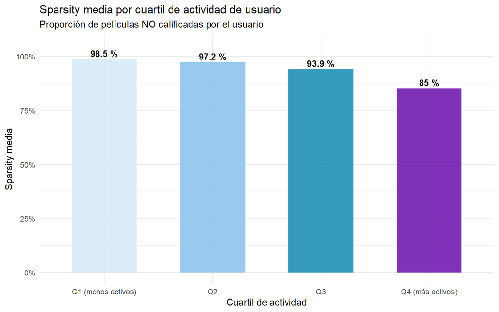

Sparsity por grupo de actividad de usuario

```r
rat_por_user$cuartil <- cut(
  rat_por_user$n_rat,
  breaks = quantile(rat_por_user$n_rat, probs = c(0, 0.25, 0.5, 0.75, 1)),
  labels = c("Q1 (menos activos)", "Q2", "Q3", "Q4 (más activos)"),
  include.lowest = TRUE
)

sparsity_cuartil <- rat_por_user |>
  group_by(cuartil) |>
  summarise(
    n_usuarios      = n(),
    ratings_medio   = round(mean(n_rat), 1),
    sparsity_media  = round(1 - mean(n_rat) / n_items, 4),
    .groups = "drop"
  )

ggplot(sparsity_cuartil, aes(x = cuartil, y = sparsity_media, fill = cuartil)) +
  geom_col(width = 0.6, alpha = 0.85) +
  geom_text(aes(label = paste0(round(sparsity_media * 100, 1), " %")),
            vjust = -0.4, size = 3.5, fontface = "bold") +
  scale_fill_manual(values = c("#d6eaf8", "#85c1e9", COL_F, COL_A)) +
  scale_y_continuous(labels = percent_format(), limits = c(0, 1.05)) +
  labs(title    = "Sparsity media por cuartil de actividad de usuario",
       subtitle = "Proporción de películas NO calificadas por el usuario",
       x = "Cuartil de actividad", y = "Sparsity media") +
  theme(legend.position = "none")
```

> La sparsity disminuye con la actividad, pero incluso los usuarios más activos (Q4) dejaron sin calificar el 85 % del catálogo. Esto confirma que la matriz es estructuralmente sparse: no es un problema de calidad de datos, sino una característica inherente del dominio. La binarización posterior maneja esta estructura de forma correcta al tratar las ausencias como “no visto”, no como dato faltante.

Sparsity por cuartil de actividad de usuario

| Cuartil de actividad | N usuarios | Ratings medio / usuario | Sparsity media |
| --- | --- | --- | --- |
| Q1 (menos activos) | 237 | 24.5 | 0.9853 |
| Q2 | 239 | 47.1 | 0.9717 |
| Q3 | 231 | 102.2 | 0.9386 |
| Q4 (más activos) | 236 | 248.8 | 0.8505 |

## 5.6 Películas más Valoradas (ratings ≥ 4)

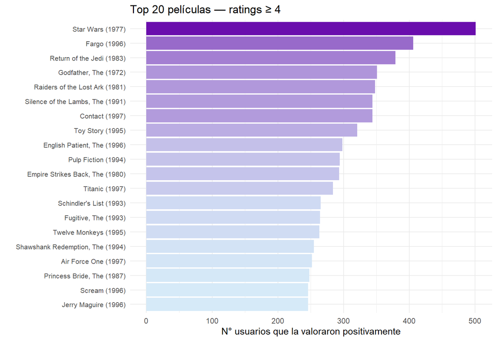

Top 20 películas con más ratings positivos (≥ 4)

```r
rat_ml <- as(MovieLense, "data.frame")
names(rat_ml) <- c("user", "item", "rating")

top_pelis <- rat_ml |>
  filter(rating >= 4) |>
  count(item, sort = TRUE) |>
  slice_head(n = 20)

ggplot(top_pelis, aes(x = reorder(item, n), y = n, fill = n)) +
  geom_col() +
  coord_flip() +
  scale_fill_gradient(low = "#d6eaf8", high = COL_A) +
  labs(title = "Top 20 películas — ratings ≥ 4",
       x = "", y = "N° usuarios que la valoraron positivamente") +
  theme(legend.position = "none", axis.text.y = element_text(size = 8))
```

## 5.7 Análisis por Género

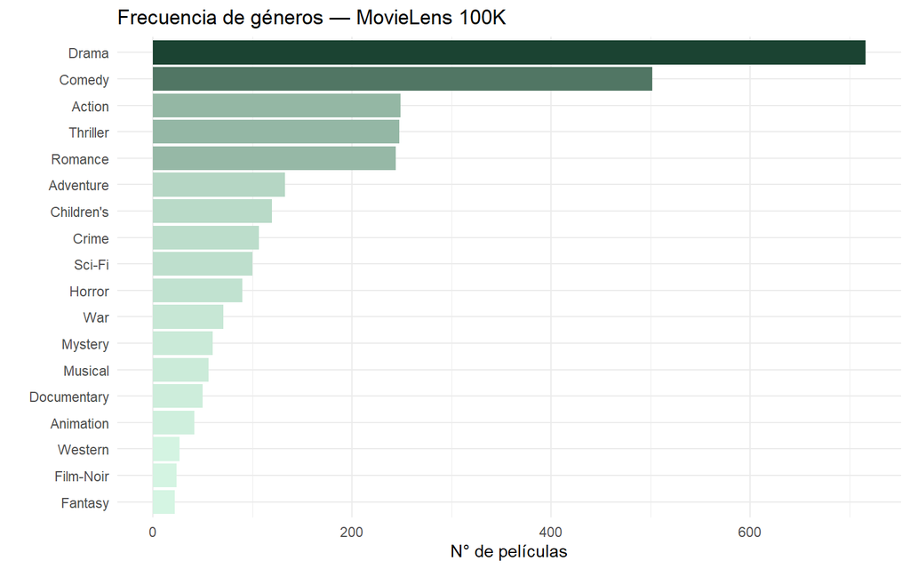

Frecuencia de géneros en el dataset

```r
movie_meta <- MovieLenseMeta
generos    <- colnames(movie_meta)[5:ncol(movie_meta)]

freq_genero <- colSums(movie_meta[, generos], na.rm = TRUE) |>
  sort(decreasing = TRUE) |>
  as.data.frame() |>
  tibble::rownames_to_column("Genero") |>
  rename(N = 2)

ggplot(freq_genero, aes(x = reorder(Genero, N), y = N, fill = N)) +
  geom_col() +
  coord_flip() +
  scale_fill_gradient(low = "#d5f5e3", high = COL_E) +
  labs(title = "Frecuencia de géneros — MovieLens 100K",
       x = "", y = "N° de películas") +
  theme(legend.position = "none")
```

Distribución de películas por género

| Género | N películas |
| --- | --- |
| Drama | 716 |
| Comedy | 502 |
| Action | 249 |
| Thriller | 248 |
| Romance | 244 |
| Adventure | 133 |
| Children's | 120 |
| Crime | 107 |
| Sci-Fi | 100 |
| Horror | 90 |
| War | 71 |
| Mystery | 60 |
| Musical | 56 |
| Documentary | 50 |
| Animation | 42 |
| Western | 27 |
| Film-Noir | 24 |
| Fantasy | 22 |

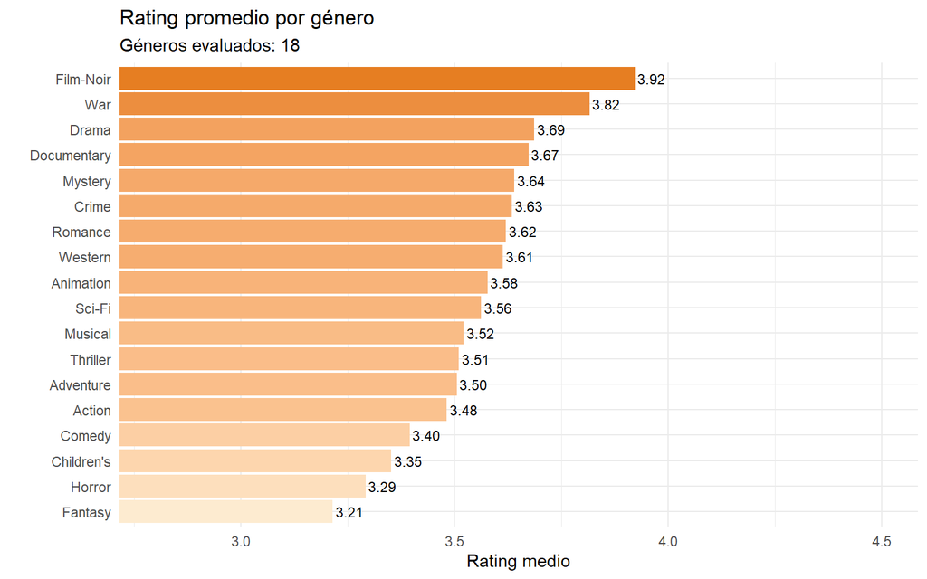

Rating promedio por género

```r
# MovieLenseMeta tiene columnas: title, year, url, + 19 géneros binarios.
# La clave de unión correcta es la columna "title", no los rownames.
# rat_ml$item es factor — se convierte a character para el join.

meta_generos <- movie_meta |>
  mutate(item = as.character(title)) |>
  select(item, all_of(generos)) |>
  mutate(across(all_of(generos), as.integer))

rat_genero <- rat_ml |>
  mutate(item = as.character(item)) |>
  inner_join(meta_generos, by = "item") |>
  pivot_longer(
    cols      = all_of(generos),
    names_to  = "genero",
    values_to = "pertenece"
  ) |>
  filter(!is.na(pertenece), pertenece == 1L) |>
  group_by(genero) |>
  summarise(
    rating_medio = round(mean(rating, na.rm = TRUE), 3),
    n_ratings    = n(),
    .groups      = "drop"
  ) |>
  arrange(desc(rating_medio))

ggplot(rat_genero, aes(x = reorder(genero, rating_medio),
                       y = rating_medio, fill = rating_medio)) +
  geom_col() +
  geom_text(aes(label = sprintf("%.2f", rating_medio)),
            hjust = -0.1, size = 3.2) +
  coord_flip(ylim = c(2.8, 4.5)) +
  scale_fill_gradient(low = "#fdebd0", high = "#e67e22") +
  labs(title    = "Rating promedio por género",
       subtitle = paste0("Géneros evaluados: ", nrow(rat_genero)),
       x = "", y = "Rating medio") +
  theme(legend.position = "none")
```

## 5.8 Resumen de Diagnóstico de Calidad

Resumen del diagnóstico de calidad de datos

| Dimensión | Resultado |
| --- | --- |
| Valores faltantes imputables | 0 — ninguno |
| NA estructural (no-vistos) | 1 469 760 celdas (93.67 %) |
| Usuarios outlier (actividad extrema) | 41 usuarios (actividad extrema, retener) |
| Películas outlier (popularidad extrema) | 128 películas (popularidad extrema, retener) |
| Usuarios sin ningún rating | 0 — dataset limpio por diseño |
| Películas sin ningún rating | 0 — dataset limpio por diseño |
| Umbral binarización válido (rating ≥ 4) | 55.4 % de ratings son 4 o 5 ✓ |
| Acción requerida | Solo filtros 4a (soporte) y 4b (correlación) — no imputación |

# 6 Paso 3: Preprocesamiento: Binarización

```r
# binarizeMF fue eliminada de recommenderlab >= 0.2-7.
# Conversión segura: data.frame largo → lista de ítems por usuario → transactions.
rat_long <- as(MovieLense, "data.frame")
names(rat_long) <- c("user", "item", "rating")

# Lista: por cada usuario, vector de títulos con rating >= 4
tx_lista <- split(
  as.character(rat_long$item[rat_long$rating >= 4]),
  rat_long$user[rat_long$rating >= 4]
)

trans_ml <- as(tx_lista, "transactions")

n_pos    <- sum(size(trans_ml))
dens_bin <- round(n_pos / (length(trans_ml) * length(itemLabels(trans_ml))), 4)

cat(
  "── Binarización (rating ≥ 4) ───────────────────────────\n",
  "Usuarios              :", length(trans_ml),               "\n",
  "Películas             :", length(itemLabels(trans_ml)),   "\n",
  "Interacciones pos.    :", n_pos,                          "\n",
  "Densidad binaria      :", dens_bin,                       "\n",
  "N transacciones       :", length(trans_ml),               "\n",
  "Tamaño medio tx       :", round(mean(size(trans_ml)), 1), "\n",
  "Tamaño mín / máx      :", min(size(trans_ml)), "/", max(size(trans_ml)), "\n"
)
```

```
── Binarización (rating ≥ 4) ───────────────────────────
 Usuarios              : 942
 Películas             : 1433
 Interacciones pos.    : 55024
 Densidad binaria      : 0.0408
 N transacciones       : 942
 Tamaño medio tx       : 58.4
 Tamaño mín / máx      : 3 / 376
```

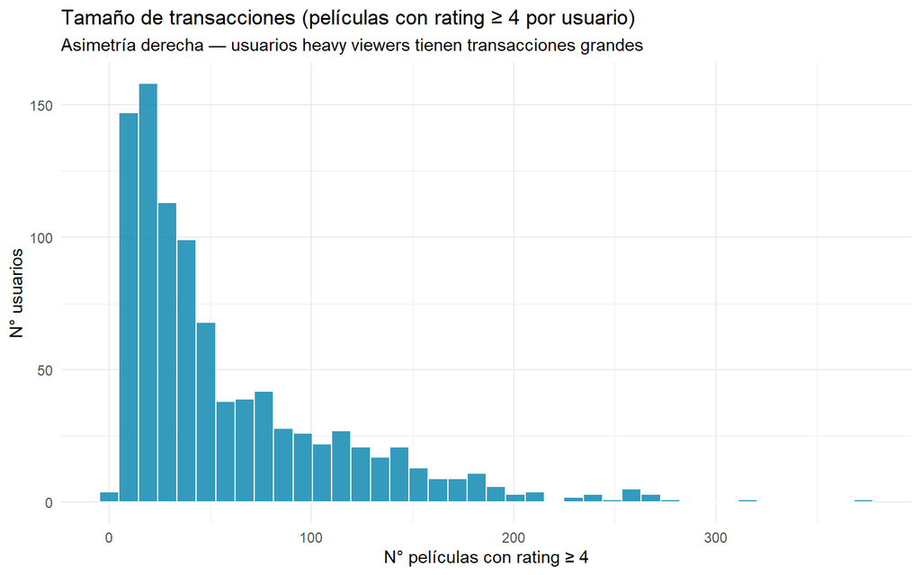

Distribución del tamaño de transacciones por usuario

```r
data.frame(size = size(trans_ml)) |>
  ggplot(aes(x = size)) +
  geom_histogram(bins = 40, fill = COL_F, color = "white", alpha = 0.85) +
  labs(title    = "Tamaño de transacciones (películas con rating ≥ 4 por usuario)",
       subtitle = "Asimetría derecha — usuarios heavy viewers tienen transacciones grandes",
       x = "N° películas con rating ≥ 4", y = "N° usuarios")
```

> La mayoría de los usuarios valoró positivamente entre 10 y 50 películas. La distribución es asimétrica a la derecha: pocos usuarios tienen transacciones grandes (más de 200 películas con rating ≥ 4), mientras que la masa se concentra en transacciones pequeñas. Esto es esperable — los *heavy viewers* son minoría. Las transacciones pequeñas generan menos reglas por usuario, pero al ser la mayoría dominan los patrones globales extraídos por los algoritmos.